# note13(1)

### 예제1

`-` 주사위 2개를 던져서 확률변수 $X$와 $Y$를 아래와 같이 정의하자.

- $X$: 첫번째 주사위를 던졌을때 나오는 숫자. ($X=1,2,3,4,5,6$)
- $Y$: 두 주사위의 합 ($Y=2,3,\dots,12$)

`–` $X,Y$의 확률질량 함수를 구하면 아래와 같다.

| $x$ | 1 | 2 | 3 | 4 | 5 | 6 |
| --- | --- | --- | --- | --- | --- | --- |
| $p(x)$ | 1/6 | 1/6 | 1/6 | 1/6 | 1/6 | 1/6 |

| $y$ | 2 | 3 | 4 | 5 | 6 | 7 | 8 | 9 | 10 | 11 | 12 |
| --- | --- | --- | --- | --- | --- | --- | --- | --- | --- | --- | --- |
| $p(x)$ | 1/36 | 2/36 | 3/36 | 4/36 | 5/36 | 6/36 | 5/36 | 4/36 | 3/36 | 2/36 | 1/36 |

`–` 확률변수 $X$와 $Y$를 만드는법

```r
X=sample(1:6,size=5000,replace=T)
print(head(X))
```

```
[1] 3 6 2 6 3 3
```

```r
Y=X+sample(1:6,size=5000,replace=T)
print(head(Y))
```

```
[1]  6 11  4  8  8  6
```

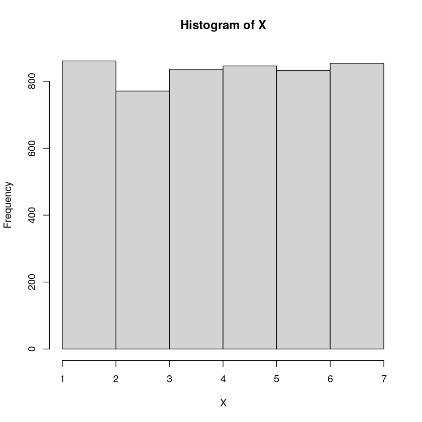

```r
hist(X,1:7,right=F)
```

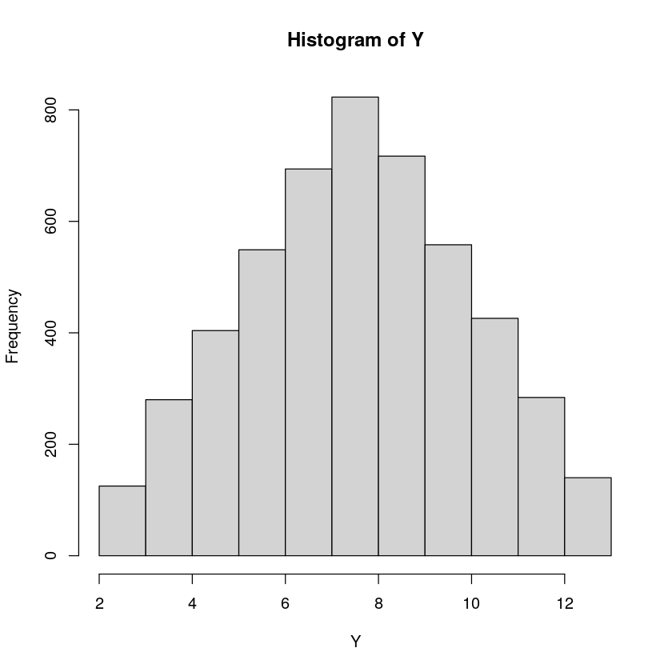

```r
hist(Y,2:13,right=F)
```

`–` $Y=y$를 알고 있을떄 $X$를 쉽게 얻을 수 있을까?

- $P(X|Y=y)=?$

| y | x |
| --- | --- |
| 2 | 1 |
| 3 | 1,2 |
| 4 | 1,2,3 |
| 5 | 1,2,3,4 |
| 6 | 1,2,3,4,5 |
| 7 | 1,2,3,4,5,6 |
| 8 | 2,3,4,5,6 |
| 9 | 3,4,5,6 |
| 10 | 4,5,6 |
| 11 | 5,6 |
| 12 | 6 |

`–` 수식으로 요약하면

- $y\leq 7$: $x$는 $1\sim (y-1)$사이의 숫자를 랜덤으로 뽑는다.
- $y>7$: $x$는 $(y-6)\sim 6$사이의 숫자를 랜덤으로 뽑는다.

```r
fx_giveny<-function(y){
    if(y==12){
        x<-6
    } else if(y>7){
        x<-sample((y-6):6,size=1)
    }else{
        x<-sample(1:(y-1),size=1)
    }
    x
}
```

`-` 그렇다면 아래와 같이 샘플링 할 수도 있지 않을까?

($random \sim$ 주사위)

- $x_1$을 뽑는다. $x_1=random$
- $y_1$은 $x_1$을 이용하여 추출한다. 즉 $y_1=x_1+random$
- $x_2$는 $y_1$을 이용하여 추출한다 즉 $x_2 \sim f(x_2|y_1)$
- $y_2$는 다시 $x_2$를 이용하여 추출한다. 즉 $y_2=x_2+random$

...

```r
set.seed(3)
x<-c()
y<-c()
x[1]<-sample(1:6,size=1)
y[1]<-x[1]+sample(1:6,size=1)
```

```r
x[1]
```

5

```r
y[1]
```

7

```r
x[2]<-fx_giveny(y[1])
y[2]<-x[2]+sample(1:6,size=1)
```

```r
print(x)
```

```
[1] 5 4
```

```r
print(y)
```

```
[1] 7 8
```

```r
x[3]<-fx_giveny(y[2])
y[3]<-x[3]+sample(1:6,size=1)
```

```r
print(x)
```

```
[1] 5 4 3
```

```r
print(y)
```

```
[1] 7 8 6
```

```r
x[4]<-fx_giveny(y[3])
y[4]<-x[4]+sample(1:6,size=1)
```

```r
print(x)
```

```
[1] 5 4 3 4
```

```r
print(y)
```

```
[1] 7 8 6 6
```

```r
set.seed(3)
x<-c()
y<-c()
x[1]<-sample(1:6,size=1)
for(i in 1:5000){
    y[i]<-x[i]+sample(1:6,size=1)
    x[i+1]<-fx_giveny(y[i])
}
```

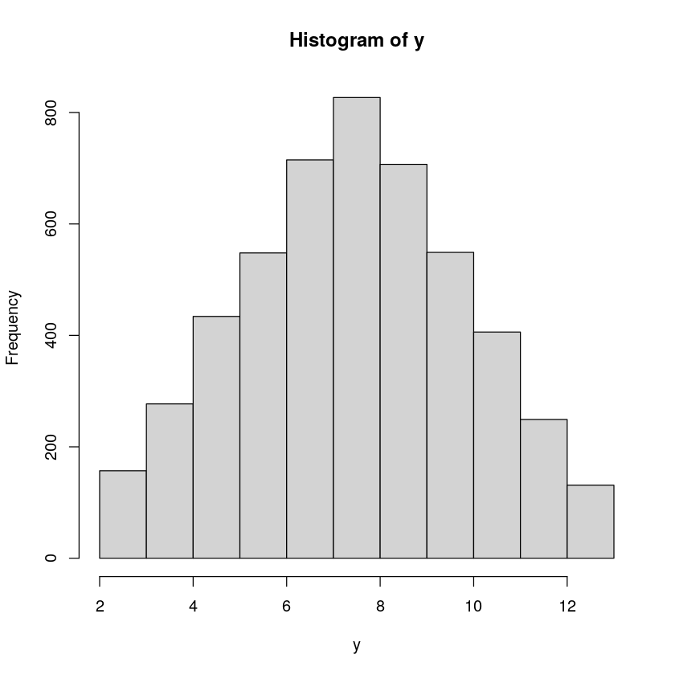

```r
hist(y,2:13,right=F)
```

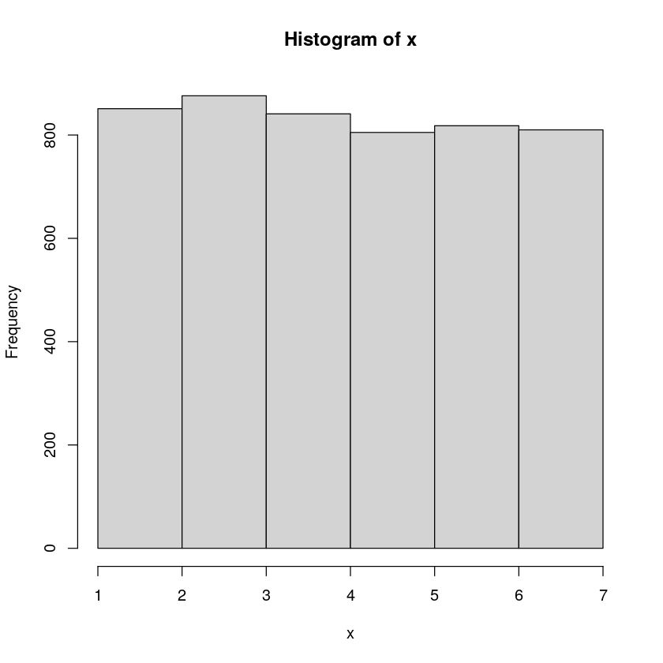

```r
hist(x,1:7,right=F)
```

### 깁스샘플링이 가능한 이유

`-` $X$ 만 따져보자.

detailed balance condition은 아래와 같다.

$$transition(x_t \to x_{t+1})f(x_t)=transition(x_{t+1} \to x_t)f(x_{t+1})$$

임을 보이면 된다.

`-` 우리의 예제의 경우는 아래를 보이면 된다.

- $transition(1\to 1 )\pi(1)= transition (1\to 1 )\pi(1)$
- $transition(1\to 2 )\pi(1)= transition (2\to 1 )\pi(2)$
- ...
- $transition(1\to 6 )\pi(1)= transition (6\to 1 )\pi(6)$
- ...
- $transition(6\to 6 )\pi(6)= transition (6\to 6 )\pi(6)$

노가다를 활용하면 성립함을 알 수 있다.

`-` $\{Y_t\}$역시 노가다를 활용하여 staionary process임을 확인 할 수 있다.

`-` conditional을 이미 알고 있다고 가정하였고, marginal을 시뮬레이션 할 수 있으므로 joint를 시뮬레이션으로 뽑을 수 있다.

### 깁스샘플링 (알고리즘 )

#### 2차원

`-` $X_0=x_0$를 선택

`-` $t=1,2,\dots$ 에 대하여 아래를 반복하면서 샘플링한다.

- $Y_t \sim f_{Y|X}(\cdot|x_{t-1})$
- $X_t \sim f_{X|Y}(\cdot|y_t)$

#### 다차원

`-` ${\bf x}^{(t)}=(x_1^{(t)},\dots, x_p^{(t)})$가 주어졌을때 아래를 반복

- $X_1^{(t+1)} \sim f_1(x_1| x_{2}^{(t)},\dots,x_p^{(t)})$
- $X_2^{(t+1)} \sim f_2(x_2| x_{1}^{(t+1)}, x_{3}^{(t)}, \dots, x_p^{(t)})$
- $\dots$
- $X_p^{(t+1)} \sim f_p(x_p| x_{1}^{(t+1)},\dots x_{p-1}^{(t+1)})$

느낌: 나 빼고 다른 $p-1$의 값이 다 뽑혔으면 그걸 바탕으로 나도 1차원 랜덤변수를 만들 수 있음.

`-` 첫 시작은 누가?